# Association results under arm-by-smoking model

Andrey Ziyatdinov

2017-07-03

# 1 Model comparison

## 1.1 Test on `arm_smk0`

- Null model `arm`:

$var(y) = \sigma_{g}^2 A + \sigma_{e}^2 I$

- Alternative model `arm_smk0`

$var(y) = \sigma_{g}^2 A + \begin{pmatrix} \sigma_{e1}^2 I & 0 \\ 0 & \sigma_{e2}^2 I \end{pmatrix}$

- Difference in the number of parameters (`df` in the LRT test): 1

| trait | stat | pval |
| --- | --- | --- |
| FVC_utah | 21.32030 | 3.885943e-06 |
| TLCpp_race_adjusted | 30.03545 | 4.242198e-08 |
| FVCpp_utah | 44.80477 | 2.176913e-11 |
| log_pctEmph_Slicer | 45.90741 | 1.239761e-11 |
| FEV1_utah | 63.27842 | 1.794598e-15 |
| FEV1pp_utah | 103.40528 | 2.731460e-24 |
| FEV1_FVC_utah | 243.71078 | 6.104018e-55 |

Example code for `FEV1_FVC_utah` trait:

```r
(mod_null <- copdgene_lmer_mod("FEV1_FVC_utah", "arm", REML = FALSE))
```

```
Linear mixed model fit by maximum likelihood  ['lmerMod']
Formula: FEV1_FVC_utah ~ Age_Enroll + Age_Enroll2 + gender + SmokCigNow +
    ATS_PackYears + acs_global + (1 | ccenter) + (1 | sid)
   Data: phen
      AIC       BIC    logLik  deviance  df.resid
-4445.110 -4384.215  2232.555 -4465.110      3250
Random effects:
 Groups   Name        Std.Dev.
 sid      (Intercept) 0.01324
 ccenter  (Intercept) 0.02733
 Residual             0.12069
Number of obs: 3260, groups:  sid, 3260; ccenter, 21
Fixed Effects:
  (Intercept)     Age_Enroll    Age_Enroll2        gender2    SmokCigNow1
    1.0421125     -0.0063324     -0.0000149      0.0155071      0.0641184
ATS_PackYears     acs_global
   -0.0003278     -0.0204363
```

```r
(mod_alt <- copdgene_lmer_mod("FEV1_FVC_utah", "arm_smk0", REML = FALSE))
```

```
Linear mixed model fit by maximum likelihood  ['lmerMod']
Formula: FEV1_FVC_utah ~ Age_Enroll + Age_Enroll2 + gender + SmokCigNow +
    ATS_PackYears + acs_global + (1 | ccenter) + (1 | sid) +
    (0 + dummy(SmokCigNowRev) | rsid)
   Data: phen
      AIC       BIC    logLik  deviance  df.resid
-4686.820 -4619.836  2354.410 -4708.820      3249
Random effects:
 Groups   Name                 Std.Dev.
 rsid     dummy(SmokCigNowRev) 0.13030
 sid      (Intercept)          0.01193
 ccenter  (Intercept)          0.02110
 Residual                      0.10623
Number of obs: 3260, groups:  rsid, 3260; sid, 3260; ccenter, 21
Fixed Effects:
  (Intercept)     Age_Enroll    Age_Enroll2        gender2    SmokCigNow1
    1.052e+00     -6.580e-03     -6.126e-05      1.479e-02      6.313e-02
ATS_PackYears     acs_global
   -2.424e-04     -1.522e-02
```

```r
loglik_null <- logLikNum(mod_null)
loglik_alt <- logLikNum(mod_alt)

(stat <- 2 * (loglik_alt - loglik_null))
```

```
[1] 243.7108
```

```r
(pval <- pchisq(stat, df = 1, lower = FALSE))
```

```
[1] 6.104018e-55
```

## 1.2 Test on `arm_by_smk_vareq`

- Null model `arm_smk0`

$var(y) = \sigma_{g}^2 A + \begin{pmatrix} \sigma_{e1}^2 I & 0 \\ 0 & \sigma_{e2}^2 I \end{pmatrix}$

- Alternative model `arm_by_smk_vareq`

$var(y) = \sigma^2_{g} \begin{pmatrix} A & \rho_g A\\ \rho_g A & A \end{pmatrix} + \begin{pmatrix} \sigma_{e1}^2 I & 0 \\ 0 & \sigma_{e2}^2 I \end{pmatrix}$

- Difference in the number of parameters (`df` in the LRT test): 1

| trait | stat | pval |
| --- | --- | --- |
| FEV1_FVC_utah | NA | NA |
| FEV1pp_utah | NA | NA |
| FEV1_utah | NA | NA |
| FVCpp_utah | NA | NA |
| FVC_utah | NA | NA |
| log_pctEmph_Slicer | NA | NA |
| TLCpp_race_adjusted | NA | NA |

## 1.3 Test on `arm_by_smk`

- Null model `arm_smk0`

$var(y) = \sigma_{g}^2 A + \begin{pmatrix} \sigma_{e1}^2 I & 0 \\ 0 & \sigma_{e2}^2 I \end{pmatrix}$

- Alternative model `arm_by_smk`

$var(y) = \begin{pmatrix} \sigma_{g1}^2 A & \rho_g \sigma_{g1} \sigma_{g2} A\\ \rho_g \sigma_{g1} \sigma_{g2} A & \sigma_{g2}^2 A \end{pmatrix} + \begin{pmatrix} \sigma_{e1}^2 I & 0 \\ 0 & \sigma_{e2}^2 I \end{pmatrix}$

- Difference in the number of parameters (`df` in the LRT test): 2

| trait | stat | pval |
| --- | --- | --- |
| TLCpp_race_adjusted | 0.2666266 | 0.87519086 |
| FEV1_FVC_utah | 1.1862229 | 0.55260521 |
| FVC_utah | 3.4574506 | 0.17751054 |
| FEV1pp_utah | 3.7244103 | 0.15532972 |
| log_pctEmph_Slicer | 4.2840693 | 0.11741570 |
| FVCpp_utah | 5.4145500 | 0.06671837 |
| FEV1_utah | NA | NA |

# 2 Marginal scans

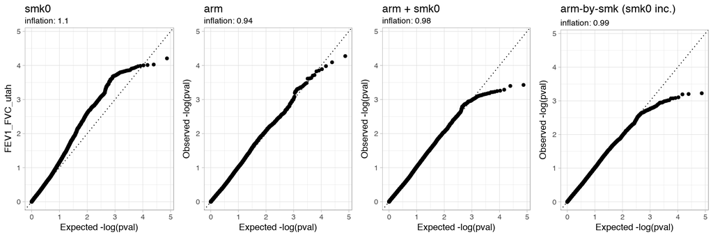

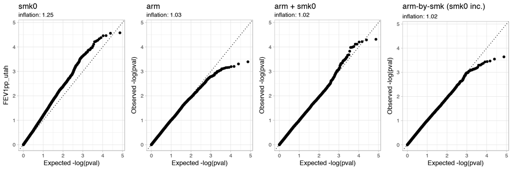

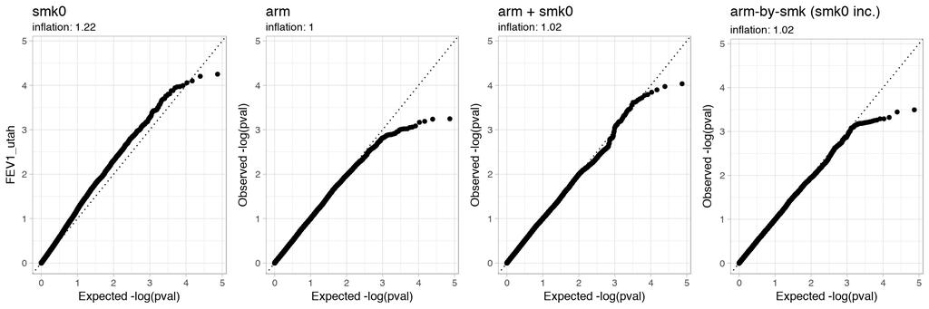

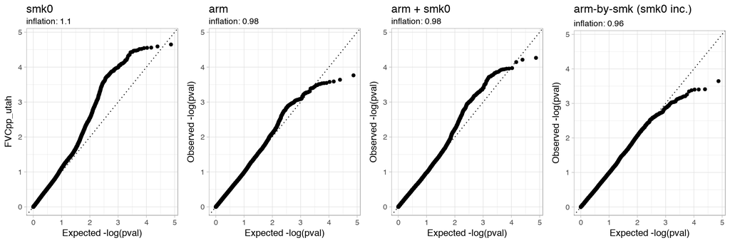

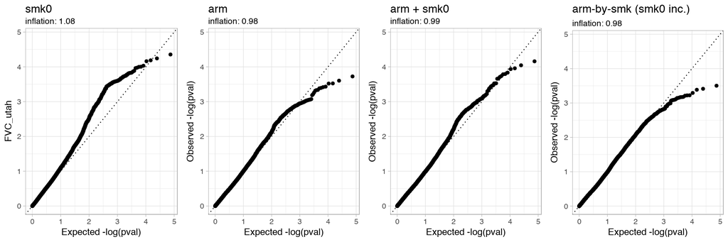

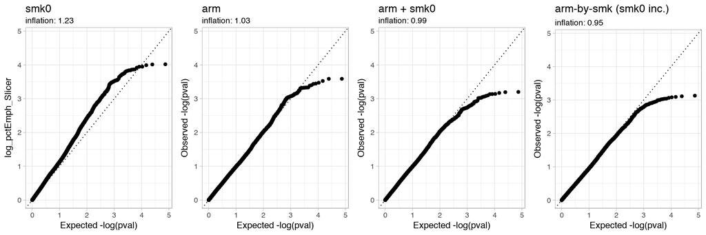

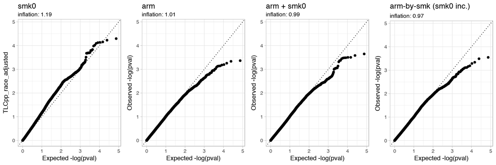

# 3 Interaction scans

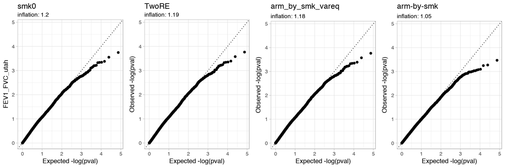

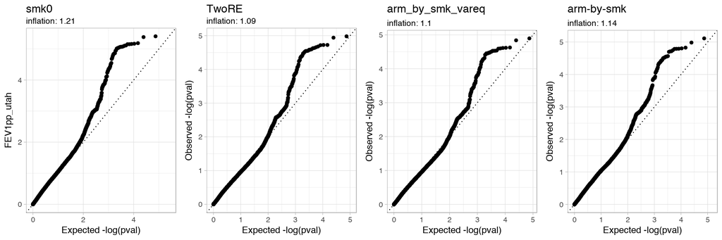

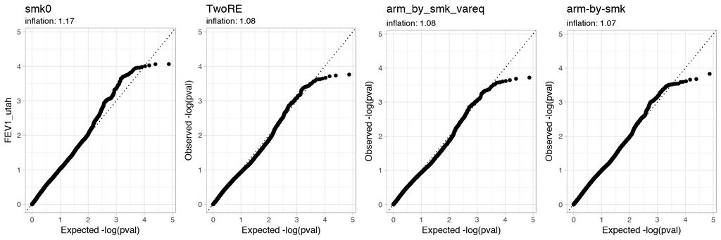

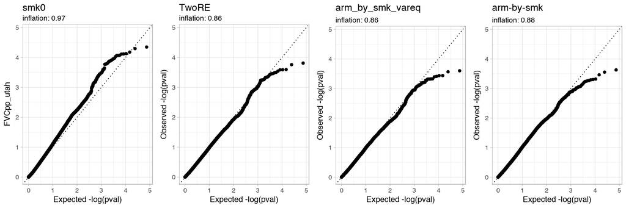

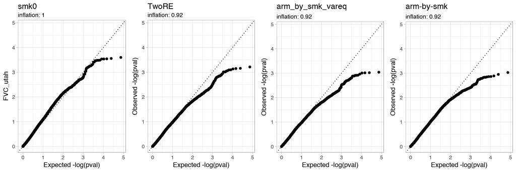

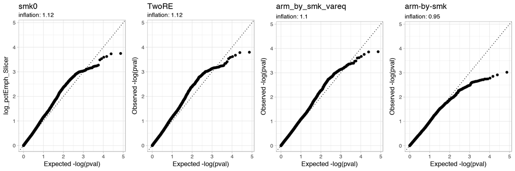

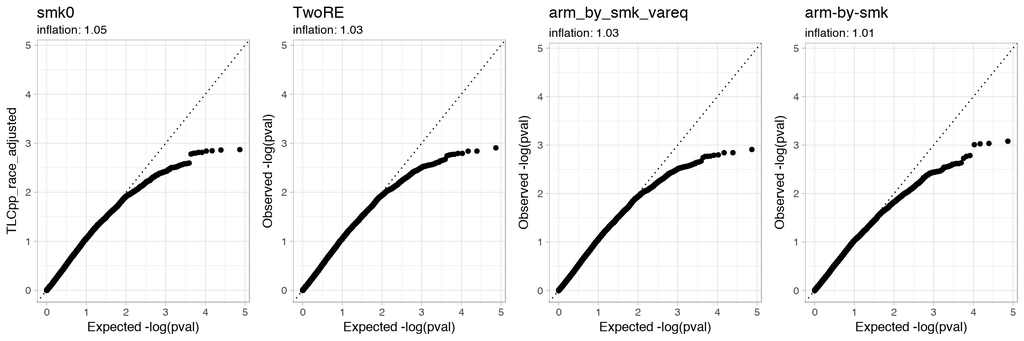

# 4 Test other smoking variables

```
 matlmResults (3,300 samples, 14 predictors)
  --   40  samples omitted

 - formula:  FEV1_FVC_utah ~ Age_Enroll + Age_Enroll2 + gender + SmokCigNow +      ATS_PackYears + acs_global
  --  weighted by var-cov matrix

 - top results 5 / 14:
             predictor    zscore         pval
1     CigPerDaySmokAvg  4.008705 6.105255e-05
2         SmokCigarReg  3.879487 1.046769e-04
3     Duration_Smoking -3.615921 2.992815e-04
4         SmokCigarNow  3.498099 4.685867e-04
5 log_CigPerDaySmokAvg  3.038217 2.379827e-03

 - computation time 7.34 sec on 1 core(s)
 matlmResults (3,300 samples, 14 predictors)
  --   40  samples omitted

 - formula:  FEV1pp_utah ~ Age_Enroll + gender + SmokCigNow + ATS_PackYears +      acs_global
  --  weighted by var-cov matrix

 - top results 5 / 14:
             predictor    zscore         pval
1     CigPerDaySmokAvg  4.356807 1.319738e-05
2     Duration_Smoking -4.153866 3.269047e-05
3         SmokCigarNow  3.773625 1.608925e-04
4           OthSmokYrs -3.558274 3.733004e-04
5 log_CigPerDaySmokAvg  3.151796 1.622699e-03

 - computation time 7.48 sec on 1 core(s)
 matlmResults (3,300 samples, 14 predictors)
  --   40  samples omitted

 - formula:  FEV1_utah ~ Age_Enroll + Age_Enroll2 + gender + Height_CM + SmokCigNow +      ATS_PackYears + acs_global
  --  weighted by var-cov matrix

 - top results 5 / 14:
             predictor    zscore         pval
1     Duration_Smoking -4.481321 7.418249e-06
2     CigPerDaySmokAvg  4.299024 1.715523e-05
```

[output cut: 50 more lines]

```
 matlmResults (3,300 samples, 14 predictors)
  --   268  samples omitted

 - formula:  TLCpp_race_adjusted ~ Age_Enroll + gender + SmokCigNow + ATS_PackYears +      acs_global
  --  weighted by var-cov matrix

 - top results 5 / 14:
             predictor    zscore         pval
1     CigPerDaySmokAvg -3.381185 0.0007217388
2     Duration_Smoking  3.276896 0.0010495500
3 log_CigPerDaySmokAvg -2.092541 0.0363901169
4         SmokCigarReg -1.850465 0.0642465641
5         SmokStartAge -1.830323 0.0672015818

 - computation time 5.95 sec on 1 core(s)
```

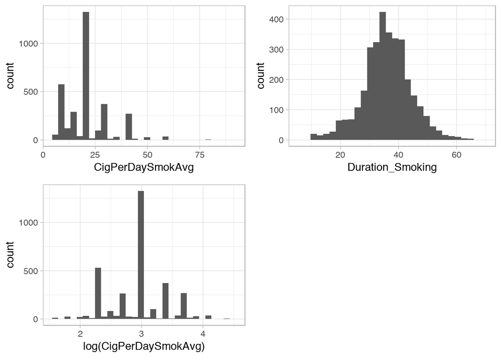

# 5 Appendix 1: Model convergence

## 5.1 `arm_by_smk`, REML

| trait | model | REML | opt | lme4 |
| --- | --- | --- | --- | --- |
| FEV1_utah | arm_by_smk | TRUE | 0 | -3 |
| FVC_utah | arm_by_smk | TRUE | 0 | -3 |
| FEV1_FVC_utah | arm_by_smk | TRUE | 0 | 0 |
| FEV1pp_utah | arm_by_smk | TRUE | 0 | 0 |
| FVCpp_utah | arm_by_smk | TRUE | 0 | 0 |
| log_pctEmph_Slicer | arm_by_smk | TRUE | 0 | 0 |
| TLCpp_race_adjusted | arm_by_smk | TRUE | 0 | 0 |

### 5.1.1 Problematic models

```
Linear mixed model fit by REML ['lmerMod']
Formula:
FEV1_utah ~ Age_Enroll + Age_Enroll2 + gender + Height_CM + SmokCigNow +
    ATS_PackYears + acs_global + (1 | ccenter) + (0 + SmokCigNow |
    sid) + (0 + dummy(SmokCigNowRev) | rsid)
   Data: phen
REML criterion at convergence: 6021.83
Random effects:
 Groups   Name                 Std.Dev. Corr
 rsid     dummy(SmokCigNowRev) 0.45645
 sid      SmokCigNow0          0.00000
          SmokCigNow1          0.08899   NaN
 ccenter  (Intercept)          0.13068
 Residual                      0.56650
Number of obs: 3260, groups:  rsid, 3260; sid, 3260; ccenter, 21
Fixed Effects:
  (Intercept)     Age_Enroll    Age_Enroll2        gender2      Height_CM
    0.1089178     -0.0375324      0.0002877     -0.4475783      0.0270611
  SmokCigNow1  ATS_PackYears     acs_global
    0.3275922     -0.0011235     -0.5200685
convergence code 0; 2 optimizer warnings; 0 lme4 warnings
```

```
Linear mixed model fit by REML ['lmerMod']
Formula:
FVC_utah ~ Age_Enroll + Age_Enroll2 + gender + Height_CM + SmokCigNow +
    ATS_PackYears + acs_global + (1 | ccenter) + (0 + SmokCigNow |
    sid) + (0 + dummy(SmokCigNowRev) | rsid)
   Data: phen
REML criterion at convergence: 6186.218
Random effects:
 Groups   Name                 Std.Dev. Corr
 rsid     dummy(SmokCigNowRev) 0.3510
 sid      SmokCigNow0          0.0000
          SmokCigNow1          0.0877    NaN
 ccenter  (Intercept)          0.1138
 Residual                      0.5936
Number of obs: 3260, groups:  rsid, 3260; sid, 3260; ccenter, 21
Fixed Effects:
  (Intercept)     Age_Enroll    Age_Enroll2        gender2      Height_CM
   -1.1834027     -0.0280542      0.0003251     -0.6434027      0.0376242
  SmokCigNow1  ATS_PackYears     acs_global
    0.2844972     -0.0002507     -0.6488107
convergence code 0; 2 optimizer warnings; 0 lme4 warnings
```

## 5.2 `arm_by_smk`, ML

| trait | model | REML | opt | lme4 |
| --- | --- | --- | --- | --- |
| FVC_utah | arm_by_smk | FALSE | 0 | -3 |
| FEV1_FVC_utah | arm_by_smk | FALSE | 0 | 0 |
| FEV1pp_utah | arm_by_smk | FALSE | 0 | 0 |
| FVCpp_utah | arm_by_smk | FALSE | 0 | 0 |
| log_pctEmph_Slicer | arm_by_smk | FALSE | 0 | 0 |
| TLCpp_race_adjusted | arm_by_smk | FALSE | 0 | 0 |
| FEV1_utah | arm_by_smk | FALSE | NA | NA |

### 5.2.1 Problematic models

```
Linear mixed model fit by maximum likelihood  ['lmerMod']
Formula:
FVC_utah ~ Age_Enroll + Age_Enroll2 + gender + Height_CM + SmokCigNow +
    ATS_PackYears + acs_global + (1 | ccenter) + (0 + SmokCigNow |
    sid) + (0 + dummy(SmokCigNowRev) | rsid)
   Data: phen
      AIC       BIC    logLik  deviance  df.resid
 6144.571  6229.824 -3058.285  6116.571      3246
Random effects:
 Groups   Name                 Std.Dev. Corr
 rsid     dummy(SmokCigNowRev) 0.34967
 sid      SmokCigNow0          0.00000
          SmokCigNow1          0.08779   NaN
 ccenter  (Intercept)          0.10917
 Residual                      0.59306
Number of obs: 3260, groups:  rsid, 3260; sid, 3260; ccenter, 21
Fixed Effects:
  (Intercept)     Age_Enroll    Age_Enroll2        gender2      Height_CM
   -1.1820271     -0.0280596      0.0003252     -0.6433364      0.0376243
  SmokCigNow1  ATS_PackYears     acs_global
    0.2847785     -0.0002530     -0.6496559
convergence code 0; 2 optimizer warnings; 0 lme4 warnings
```

## 5.3 `arm_by_smk_vareq`, REML

| trait | model | REML | opt | lme4 |
| --- | --- | --- | --- | --- |
| FEV1_FVC_utah | arm_by_smk_vareq | TRUE | 0 | 0 |
| FEV1pp_utah | arm_by_smk_vareq | TRUE | 0 | 0 |
| FEV1_utah | arm_by_smk_vareq | TRUE | 0 | 0 |
| FVCpp_utah | arm_by_smk_vareq | TRUE | 0 | 0 |
| FVC_utah | arm_by_smk_vareq | TRUE | 0 | 0 |
| log_pctEmph_Slicer | arm_by_smk_vareq | TRUE | 0 | 0 |
| TLCpp_race_adjusted | arm_by_smk_vareq | TRUE | 0 | 0 |

## 5.4 `arm_by_smk_rho1`, REML

| trait | model | REML | opt | lme4 |
| --- | --- | --- | --- | --- |
| FEV1_FVC_utah | arm_by_smk_rho1 | TRUE | 0 | 0 |
| FEV1pp_utah | arm_by_smk_rho1 | TRUE | 0 | 0 |
| FEV1_utah | arm_by_smk_rho1 | TRUE | 0 | 0 |
| FVC_utah | arm_by_smk_rho1 | TRUE | 0 | 0 |
| log_pctEmph_Slicer | arm_by_smk_rho1 | TRUE | 0 | 0 |
| FVCpp_utah | arm_by_smk_rho1 | TRUE | NA | NA |
| TLCpp_race_adjusted | arm_by_smk_rho1 | TRUE | NA | NA |